# Week 5 - Basic Descriptives & Week 6 - Correlations & Hypothesis Testing

Patricia Rossini

10/21/2021

Using the Pew American Trends Dataset, we will use R explore basic descriptive statistics such as the mean, median, and standard deviation. We will also look at frequencies and proportions, and how to create simple frequency plots.

Then, we will look at some basic measures of association and significance tests, such as correlations, t-tests, and chi-square tests.

## R Basics

First, let’s make sure you have the packages you need. Important: you only need to install packages if it is the first time you are using R in your computer. *If you have completed this step before, just jump straight to the next section to get started*!

```r
# you may need to install packages running the following line:
install.packages("dplyr", "tidyverse", "descr", "haven")
```

Before digging in, here are some basic commands in R that you need to familiarize yourself with. We will learn more as we progress in the module. You don’t have to paste any of this in your script for this class, these are just pointers for general operations in R.

```r
# assign actions to an object
x <- "something"

# open csv files
y <- read.csv("path.csv")

# open SAV files (from SPSS)
df <- read_sav("path.sav")
#open RData files
load("file.RData")

# save as csv file
write.csv(df, "file.csv", row.names = F)

# save as RData file
save(df, file = "df.RData")
```

Note that there is a code for CSV files and another one for RData files. RData files are great to work in R because you can save multiple objects and open them all with just one command instead of loading a CSV per dataframe.

For some basic information and guidance about R and RStudio, check out these tutorials:

-[Getting started with RStudio](https://moderndive.netlify.app/1-getting-started.html)

-[R-Studio Basics by R-Ladies Sydney](https://rladiessydney.org/courses/ryouwithme/01-basicbasics-0/)

## Download the data

The [datasets](https://theuniversityofliverpool-my.sharepoint.com/:f:/g/personal/prossini_liverpool_ac_uk/Ek7qMwJw_J5OpDp3EKeVDQQB0PQ8Fbq7iRJ1MT5tJSL0kQ?e=KFxzbv) we selected for our workshop (and for your assignment) are originally from the [Pew Research Center](https://www.pewresearch.org/tools-and-resources/) and come in the form of SAV files, which is a common type of file used by SPSS. Since SPSS is a paid software (which you have access to with your student account and apps anywhere), we use R to read and manipulate SPSS files with the package “Haven”.

## Getting Started

First things first: when you open R to work on something, *you need to load the necessary packages*.

For this workshop, we will use the packages below.

```r
#loading our packages
library(dplyr)
library(haven)
library(descr)
library(ggplot2)
library(tidyverse)

# run this options line to prevent R from generating scientific notations

options(scipen=999, digits = 4)
```

Let’s load our data and assign it to an object named “df”. Replace the path with your own downloads folder containing [this file](https://theuniversityofliverpool-my.sharepoint.com/:u:/g/personal/prossini_liverpool_ac_uk/EZt5HUqjpWJLuOjcNjrLwAkB1hQRd__Jf-F86LHWznAIgw?e=lGiiDj)

```r
df <- read_sav("~/OneDrive - The University of Liverpool/Teaching/COMM747 Research Methods/Datasets/American Trends Pew/ATP W74.sav") ## replace with your path to the file. On Windows, the path will most likely start with 'C://'
```

Before doing anything else, we should inspect our data. This means looking at how many observations there are (in this case, number of survey respondents), and looking at the column names.

This dataset comes with a [PDF file](https://theuniversityofliverpool-my.sharepoint.com/:b:/g/personal/prossini_liverpool_ac_uk/EfUlnuOHSrRBiH7jngCJakIBWDAQ9SoNXWP2fsC6b3me-g?e=tpR5lL_) that contains the survey questions and their “labels”, which are the column names you will see in R. When working with this type of survey, you should always keep the PDF open to refer to the correct columns.

Using the command ‘head’, we can inspect the dataset:

```r
# this command prints the names of columns:
head(df)  #alternative colnames(df)
```

```
## # A tibble: 6 × 162
##     QKEY INTERVIEW_START_W74 INTERVIEW_END_W74   DEVICE_TYPE_W74    LANG_W74
##    <dbl> <dttm>              <dttm>                    <dbl+lbl>   <dbl+lbl>
## 1 100197 2020-09-09 23:16:59 2020-09-09 23:43:35  3 [Tablet]     1 [English]
## 2 100260 2020-09-10 23:21:54 2020-09-10 23:42:58  1 [Laptop/PC]  1 [English]
## 3 100314 2020-09-10 11:45:51 2020-09-10 11:59:36  2 [Smartphone] 1 [English]
## 4 100363 2020-09-09 18:39:30 2020-09-09 18:49:02  2 [Smartphone] 1 [English]
## 5 100446 2020-09-09 18:06:58 2020-09-09 18:13:49  1 [Laptop/PC]  1 [English]
## 6 100637 2020-09-09 21:51:40 2020-09-09 22:02:27  1 [Laptop/PC]  1 [English]
## # … with 157 more variables: FORM_W74 <dbl+lbl>, TOPICINT_a_W74 <dbl+lbl>,
## #   TOPICINT_b_W74 <dbl+lbl>, TOPICINT_c_W74 <dbl+lbl>,
## #   TOPICINT_d_W74 <dbl+lbl>, TOPICINT_e_W74 <dbl+lbl>, INEQATTN_W74 <dbl+lbl>,
## #   RACECONV_W74 <dbl+lbl>, EDUCRACE_W74 <dbl+lbl>, MINBUS_W74 <dbl+lbl>,
## #   COMMDIV_W74 <dbl+lbl>, COVID_SCI6E_W74 <dbl+lbl>, NOCVACC_a_W74 <dbl+lbl>,
## #   NOCVACC_b_W74 <dbl+lbl>, NOCVACC_c_W74 <dbl+lbl>, NOCVACC_d_W74 <dbl+lbl>,
## #   VACCNCRN_a_W74 <dbl+lbl>, VACCNCRN_b_W74 <dbl+lbl>, …
```

Then we can check all column names:

```r
# this command prints the names of columns:
names(df)  #alternative colnames(df)
```

```
##   [1] "QKEY"                         "INTERVIEW_START_W74"
##   [3] "INTERVIEW_END_W74"            "DEVICE_TYPE_W74"
##   [5] "LANG_W74"                     "FORM_W74"
##   [7] "TOPICINT_a_W74"               "TOPICINT_b_W74"
##   [9] "TOPICINT_c_W74"               "TOPICINT_d_W74"
##  [11] "TOPICINT_e_W74"               "INEQATTN_W74"
##  [13] "RACECONV_W74"                 "EDUCRACE_W74"
##  [15] "MINBUS_W74"                   "COMMDIV_W74"
##  [17] "COVID_SCI6E_W74"              "NOCVACC_a_W74"
##  [19] "NOCVACC_b_W74"                "NOCVACC_c_W74"
##  [21] "NOCVACC_d_W74"                "VACCNCRN_a_W74"
##  [23] "VACCNCRN_b_W74"               "VACCNCRN_c_W74"
##  [25] "VACCNCRN_d_W74"               "VACCNFDT_W74"
##  [27] "VACCDEV_W74"                  "VACCHAPPEN_a_W74"
##  [29] "VACCHAPPEN_b_W74"             "VACCHAPPEN_c_W74"
```

[output cut: 66 more lines]

As you can see, some names are very confusing. Looking at the PDF, we can identify some variables of interest.

In R, we can select a column in the data using the operator $ after the data name. That is, df$variable is the basic sintax to call any variable name from a dataset. Note that df is how we named the data in our working example, but this could be any other name you chose when reading the data file into R using the <- operator.

For the purposes of the workshop, let’s first look at a couple of demographics.

**Gender**

Gender (F_GENDER) is a categorical variable with 3 labels: man, women, other.

For categorical variables, we can look at the frequency of each category to get a sense of data distribution. We don’t use means or standard deviation to look at categorical variables because their ‘numbering’ is arbitrary, so these descriptive statistics would not carry a relevant interpretative meaning.

```r
print_labels(df$F_GENDER) # this tells us the labels
```

```
##
## Labels:
##  value             label
##      1             A man
##      2           A woman
##      3 In some other way
##     99           Refused
```

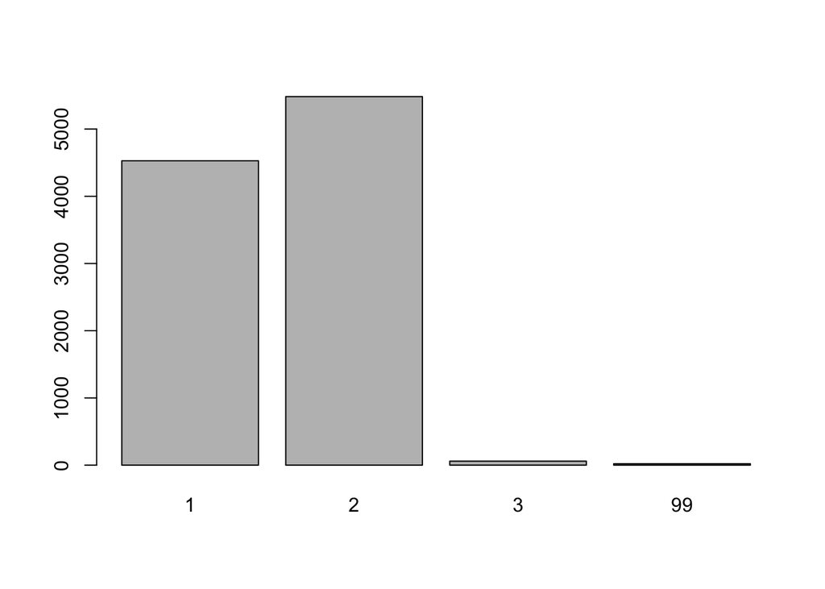

```
## Gender
##       Frequency    Percent Valid Percent
## 1          4528  44.862776       44.8672
## 2          5483  54.324780       54.3302
## 3            60   0.594471        0.5945
## 99           21   0.208065        0.2081
## NA's          1   0.009908
## Total     10093 100.000000      100.0000
```

```r
freq(df$F_GENDER) # frequency distribution of gender
```

We now know that our dataset has more women than men (54% vs 44%).

**Age**

Age can be reported as a numeric variable (when participants are asked their exact age) or as a ordinal variable, meaning that age is aggregated in specific age “bands” that are clearly in order. In the Pew data, F_AGECAT aggregates age in four categories, 18-29; 30-49; 50-64; 65+.

When age is available as a numeric variable, it is common to use basic descriptive measures such as mean and standard deviation to describe the age. Those can (in theory) be applied to ordinal variables, but they don’t make much sense in this case because there is a big gap in the ranges.

```r
print_labels(df$F_AGECAT) # this tells us the labels
```

```
##
## Labels:
##  value   label
##      1   18-29
##      2   30-49
##      3   50-64
##      4     65+
##     99 Refused
```

```r
freq(df$F_AGECAT) # frequency distribution of respondents per age range
```

```
## Age category
##       Frequency  Percent
## 1           983   9.7394
## 2          3239  32.0915
## 3          3022  29.9415
## 4          2804  27.7816
## 99           45   0.4459
## Total     10093 100.0000
```

**Mean and Standard Deviation**

We can calculate means and standard deviations using ‘base’ R functions. There are also many packages, such as “Psych”, that can you can use to create descriptive statistics. For now, let’s keep it simple.

In base R, the following functions are used to compute descriptives:

```r
mean(variable)
sd(variable)
median(variable)
summary(variable) # this gives you min and max values, mean and median
```

Since we don’t have any numeric variable in the data, let’s take the ordinal category for frequency of posting things about political and social issues on social media (AVOIDPT1) as an example

```r
print_labels(df$AVOIDPT1_W74) ## check the labels
```

```
##
## Labels:
##  value     label
##      1     Often
##      2 Sometimes
##      3    Rarely
##      4     Never
##     99   Refused
```

```r
freq(df$AVOIDPT1_W74) ## check the distribution of categories
```

```
## AVOIDPT1_W74. How often, if ever, do you post or share things about political or social issues on social media?
##       Frequency  Percent Valid Percent
## 1           796   7.8867       10.6803
## 2          1562  15.4761       20.9580
## 3          2362  23.4024       31.6919
## 4          2704  26.7908       36.2807
## 99           29   0.2873        0.3891
## NA's       2640  26.1567
## Total     10093 100.0000      100.0000
```

```r
df$AVOIDPT1_W74[df$AVOIDPT1_W74==99] <- NA ## always remove 99 before calculating means
summary(df$AVOIDPT1_W74, na.rm = TRUE) # na.rm means you are asking the function to remove NAs (missing values)
```

```
##    Min. 1st Qu.  Median    Mean 3rd Qu.    Max.    NA's
##     1.0     2.0     3.0     2.9     4.0     4.0    2669
```

```r
sd(df$AVOIDPT1_W74, na.rm = TRUE)
```

```
## [1] 1
```

Looking at the mean, we can note that on average, respondents are not very active on social media, with the majority of people posting about politics rarely or not at all.

## Examining two variables

**Crosstabulation**

Let’s start looking at crosstabulation, that is, when you use a variable (e.g. Gender) to understand another variable (e.g. posting about politics).

We can create tables in R in several ways:

```r
table(df$F_GENDER, df$AVOIDPT1_W74)
```

```
##
##         1    2    3    4
##   1   350  635  930 1057
##   2   434  911 1418 1625
##   3    12   14    9   11
##   99    0    1    5   11
```

```r
CrossTable(df$F_GENDER, df$AVOIDPT1_W74, prop.t = F, prop.chisq = F)
```

```
##    Cell Contents
## |-------------------------|
## |                       N |
## |           N / Row Total |
## |           N / Col Total |
## |-------------------------|
##
## ====================================================
##                df$AVOIDPT1_W74
## df$F_GENDER        1       2       3       4   Total
## ----------------------------------------------------
## 1                350     635     930    1057    2972
##                0.118   0.214   0.313   0.356   0.400
##                0.440   0.407   0.394   0.391
## ----------------------------------------------------
## 2                434     911    1418    1625    4388
##                0.099   0.208   0.323   0.370   0.591
##                0.545   0.584   0.600   0.601
## ----------------------------------------------------
## 3                 12      14       9      11      46
##                0.261   0.304   0.196   0.239   0.006
##                0.015   0.009   0.004   0.004
## ----------------------------------------------------
## 99                 0       1       5      11      17
##                0.000   0.059   0.294   0.647   0.002
##                0.000   0.001   0.002   0.004
## ----------------------------------------------------
## Total            796    1561    2362    2704    7423
##                0.107   0.210   0.318   0.364
## ====================================================
```

Of course, we need to remember each label (if you don’t, just call print_labels again) to interpret the table. The second table presents proportions per row and per column.

We can also plot these in a figure. For that, we will use ggplot2, from tidyverse. It’s a very flexible package and you can customize everything in your plot. Take a look at the [documentation here to start creating more elaborate plots](https://ggplot2.tidyverse.org/)

```r
#First transform the variables from labeled to factor.
#as_factor is a function of the haven package, specifically to deal with SPSS files (or other imported labeled data).

df$F_GENDER <- as_factor(df$F_GENDER)
df$AVOIDPT1_W74 <- as_factor(df$AVOIDPT1_W74)
```

To create our plot, we will use a ‘pipe’ to filter the data and remove the missing values (NAs) before we call ggplot to create the graphics.

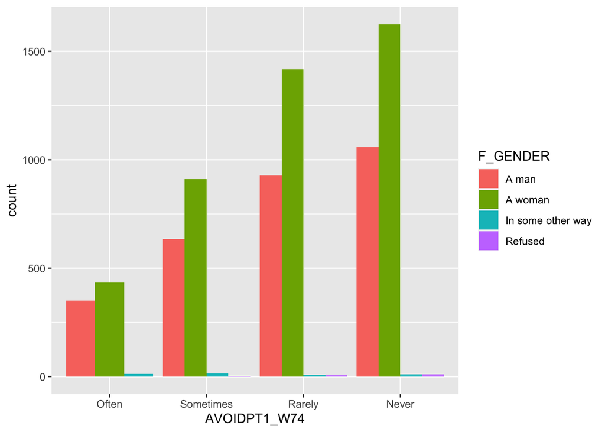

```r
# basic plot filtering out NA and undesired values
df %>%
  filter(!is.na(AVOIDPT1_W74), !is.na(F_GENDER)) %>%
  ggplot(aes(x=AVOIDPT1_W74, fill = F_GENDER)) +
  geom_bar(position = "dodge")
```

The plot can take several arguments for customization. For instance, we can add some text to it, filter more values, or change the theme.

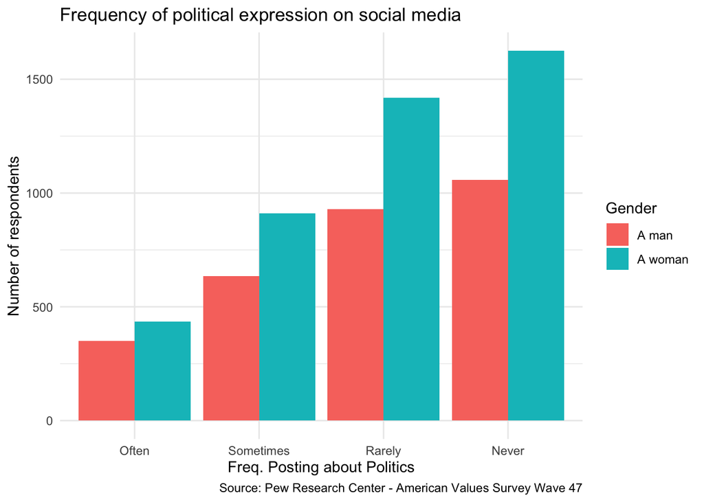

```r
df %>%
  filter(!is.na(AVOIDPT1_W74), !is.na(F_GENDER), F_GENDER != "Refused", F_GENDER != "In some other way") %>%
  ggplot(aes(x=AVOIDPT1_W74, fill = F_GENDER)) +
  geom_bar(position = "dodge") +
  labs(title = "Frequency of political expression on social media", caption = "Source: Pew Research Center - American Values Survey Wave 47", x = "Freq. Posting about Politics", y = "Number of respondents", fill = "Gender") + theme_minimal()
```

Finally, let’s create a plot using percentages. To do this, we will use pipes again to calculate percentages before creating the plot:

```r
df %>%
  filter(!is.na(AVOIDPT1_W74), !is.na(F_GENDER), F_GENDER != "Refused", F_GENDER != "In some other way") %>%
  group_by(F_GENDER, AVOIDPT1_W74) %>% # we are using this to make sure the data is grouped to calculate proportions
  summarize(n = n()) %>%
  mutate(perc = 100*n/sum(n))
```

```
## # A tibble: 8 × 4
## # Groups:   F_GENDER [2]
##   F_GENDER AVOIDPT1_W74     n  perc
##   <fct>    <fct>        <int> <dbl>
## 1 A man    Often          350 11.8
## 2 A man    Sometimes      635 21.4
## 3 A man    Rarely         930 31.3
## 4 A man    Never         1057 35.6
## 5 A woman  Often          434  9.89
## 6 A woman  Sometimes      911 20.8
## 7 A woman  Rarely        1418 32.3
## 8 A woman  Never         1625 37.0
```

If you want to keep this table as a separate object, just assign it to an object (percentages_tab is an arbitrary name I picked):

```r
percentages_tab <- df %>%
  filter(!is.na(AVOIDPT1_W74), !is.na(F_GENDER), F_GENDER != "Refused", F_GENDER != "In some other way") %>%
  group_by(F_GENDER, AVOIDPT1_W74) %>% # we are using this to make sure the data is grouped to calculate proportions
  summarize(n = n()) %>%
  mutate(perc = 100*n/sum(n))
```

Now that we learned how to calculate percentages using two variables, let’s incorporate them in the plot with another pipe:

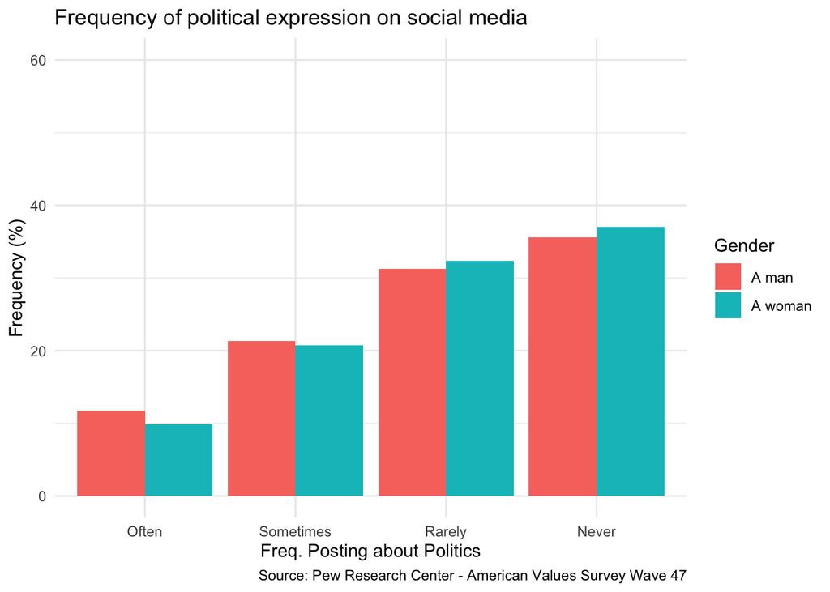

```r
df %>%
  filter(!is.na(AVOIDPT1_W74), !is.na(F_GENDER), F_GENDER != "Refused", F_GENDER != "In some other way") %>%
  group_by(F_GENDER, AVOIDPT1_W74) %>% # we are using this to make sure the data is grouped to calculate proportions
  summarize(n = n()) %>%
  mutate(perc = 100*n/sum(n)) %>%
  ggplot(aes(x= AVOIDPT1_W74, y = perc, fill = F_GENDER)) +
  geom_bar(position = "dodge",stat = "identity") + #we changed stat to identity because we
  labs(title = "Frequency of political expression on social media", caption = "Source: Pew Research Center - American Values Survey Wave 47", x = "Freq. Posting about Politics", y = "Frequency (%)", fill = "Gender") +
  theme_minimal() +
  ylim(c(0, 60)) # this determines the limits of the y axis.
```

And done :)

You can save/export the figures you created using the following code (or by clicking ‘export’ in the plots pane in RStudio):

```r
ggsave(
  filename,
  plot = last_plot(), dpi = 300)
```

To improve your skills and prepare for the assignment, take a look at the PDF ‘codebook’, select a couple of different variables and try to replicate the examples of this workshop at home.

## Calculating Correlations and Testing Hypothesis (week 6)

### Chi-Square Test

A chi-square is a type of inferential statistic, used to determine whether the differences between the nominal and/or orginal variables to determine if the differences between categories are statistically significant. Considering the variables we are investigating in our data, gender and frequency of political expression on social media, we can use a chi-square to determine whether the frequency of political expression differs by gender.

For this, let’s consider just the respondents who identified as male or female, as the other two response options had very few observations.

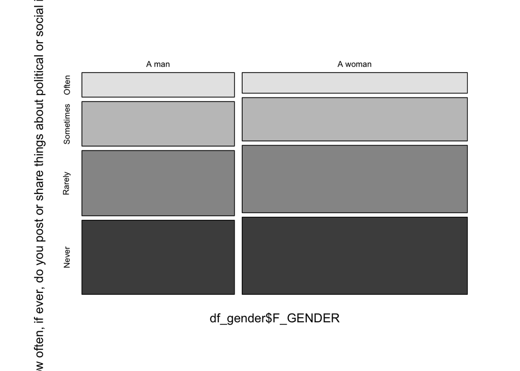

```
##    Cell Contents
## |-------------------------|
## |                   Count |
## |-------------------------|
##
## ================================================================================
##                                                          df_gender$F_GENDER
## AVOIDPT1_W74. Hw o, i e, d y p o s t a p o s i o s m?    A man   A woman   Total
## --------------------------------------------------------------------------------
## Often                                                      350       434     784
## --------------------------------------------------------------------------------
## Sometimes                                                  635       911    1546
## --------------------------------------------------------------------------------
## Rarely                                                     930      1418    2348
## --------------------------------------------------------------------------------
## Never                                                     1057      1625    2682
## --------------------------------------------------------------------------------
## Total                                                     2972      4388    7360
## ================================================================================
##
## Statistics for All Table Factors
##
## Pearson's Chi-squared test
## ------------------------------------------------------------
## Chi^2 = 7.854      d.f. = 3      p = 0.0491
##
##         Minimum expected frequency: 316.6
```

```r
df_gender <- subset(df, F_GENDER == "A man" | F_GENDER == "A woman") # this function is filtering our dataframe to only contain respondents who identify as either men or women. You will note in the Environment pane that now the dataframe has 10011 observations, 82 less than the original data. Note that we are assigning the filtered dataset to a new dataframe. This is to preserve the original data.
df_gender$F_GENDER <- droplevels(df_gender$F_GENDER) # this removes the two 'labels' we filtered

# we can use one function to plot the crosstabulation and execute the test
crosstab(df_gender$AVOIDPT1_W74, df_gender$F_GENDER,chisq = T)
```

```r
# or simply call the test and look at the result
chisq.test(df_gender$AVOIDPT1_W74, df_gender$F_GENDER) # which only returns the test results
```

```
##
##  Pearson's Chi-squared test
##
## data:  df_gender$AVOIDPT1_W74 and df_gender$F_GENDER
## X-squared = 7.9, df = 3, p-value = 0.05
```

### Correlations

Calculating Pearson’s correlation coefficient in R is simple: the most important thing is to know whether correlation is the right test for your data. As you saw in the lecture, correlations are meant to be used to determine the relationship between two quantitative variables (numeric, interval, ratio)

So let’s think about our data. So far, we have been using a nominal variable (gender) to understand frequency of political expression on social media. That wouldn’t be adequate for a correlation test. Instead, we can look at two ordinal variables: freq. of political expression and education.

These are in our dataset as labeled data/factors, so we need to first convert them to numbers and then make sure that the numeric representation of the numbers are in the correct order.

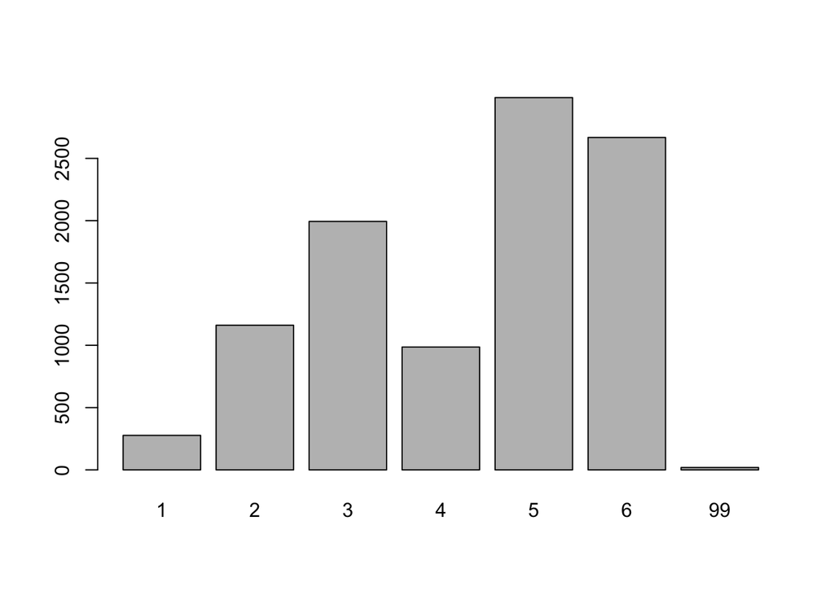

```
## Education level category 2
##       Frequency  Percent
## 1           277   2.7445
## 2          1161  11.5030
## 3          1994  19.7563
## 4           986   9.7691
## 5          2988  29.6047
## 6          2668  26.4342
## 99           19   0.1882
## Total     10093 100.0000
```

```r
#let's inspect our data first
freq(df$F_EDUCCAT2) # we have two variables for educational level, I selected the one with more values:
```

```r
print_labels(df$F_EDUCCAT2) # from here we can see that the variables are in the right order, i.e. with higher number meaning higher education.
```

```
##
## Labels:
##  value                           label
##      1           Less than high school
##      2            High school graduate
##      3         Some college, no degree
##      4              Associate's degree
##      5 College graduate/some post grad
##      6                    Postgraduate
##     99                         Refused
```

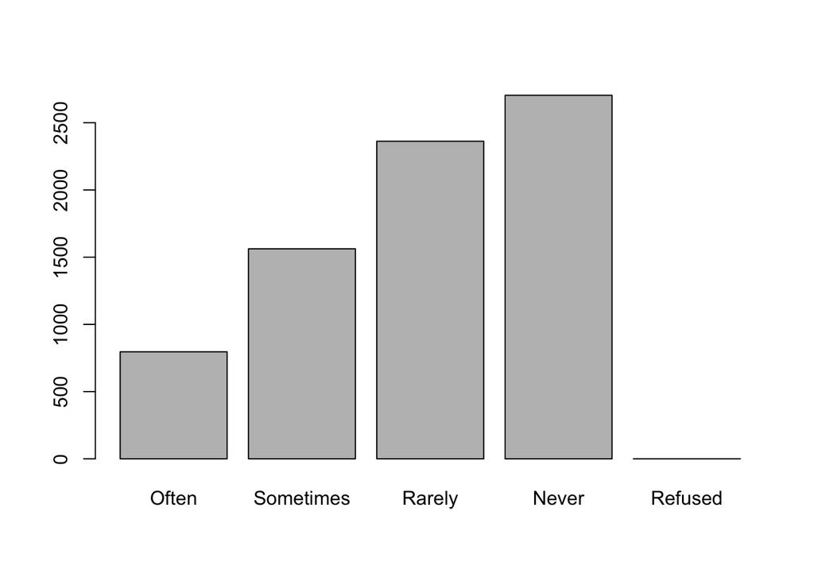

```
## AVOIDPT1_W74. How often, if ever, do you post or share things about political or social issues on social media?
##           Frequency Percent Valid Percent
## Often           796   7.887         10.72
## Sometimes      1562  15.476         21.04
## Rarely         2362  23.402         31.82
## Never          2704  26.791         36.42
## Refused           0   0.000          0.00
## NA's           2669  26.444
## Total         10093 100.000        100.00
```

```r
#because correlations deal with numeric values, we need to transform our labeled variable in numeric

df$F_EDUCCAT2 <- as.numeric(df$F_EDUCCAT2)


freq(df$AVOIDPT1_W74) # in this one, the labels are in the opposite order, with 1 meaning higher frequency and 4 lower. Let's reverse it to facilitate our interpretation:
```

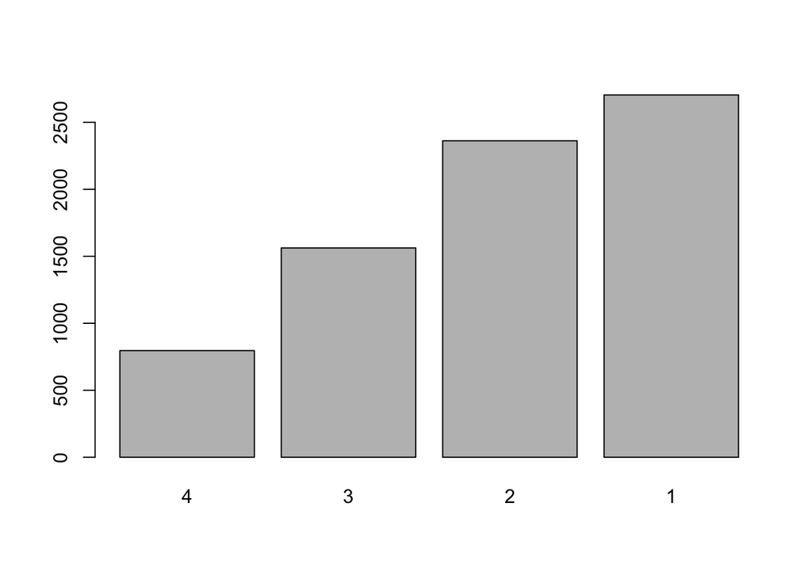

```
## df$AVOIDPT1_W74R
##       Frequency Percent Valid Percent
## 4           796   7.887         10.72
## 3          1562  15.476         21.04
## 2          2362  23.402         31.82
## 1          2704  26.791         36.42
## NA's       2669  26.444
## Total     10093 100.000        100.00
```

```r
df <- df %>% mutate(AVOIDPT1_W74R = recode_factor(as.numeric(df$AVOIDPT1_W74), '1' = '4', '2' =  '3', '3' = '2', '4' = '1'))
freq(df$AVOIDPT1_W74R) # now we check if the numbers match (they do :)
```

```r
df$AVOIDPT1_W74R <- as.numeric(df$AVOIDPT1_W74R) #making sure the variable is numeric

# now the correlation
cor.test(df$F_EDUCCAT2, df$AVOIDPT1_W74R, method = "pearson", use='complete.obs') # the use = complete.obs is to remove missing values from the data.
```

```
##
##  Pearson's product-moment correlation
##
## data:  df$F_EDUCCAT2 and df$AVOIDPT1_W74R
## t = -0.17, df = 7422, p-value = 0.9
## alternative hypothesis: true correlation is not equal to 0
## 95 percent confidence interval:
##  -0.02475  0.02075
## sample estimates:
##       cor
## -0.001999
```

We find a negative correlation (-0.001) that is not significant (p = 0.9) between educational levels and frequency of online posting, meaning that there no inverse relationship between variables.

You can also compute correlations for several variables at a time and create either a correlation table or a correlation plot [(for instance, using the package corrplot)](https://cran.r-project.org/web/packages/corrplot/vignettes/corrplot-intro.html). For this, just make sure you are selecting the correct types of variables.

## Additional functions for your report (New! Updated Nov 22)

Based on a couple of questions that surfaced from students, here are some guidelines on how to look at questions that have results in multiple columns. For instance, W74 has some questions about online harassment. The variable ON12 refers to different online environments where people who have suffered online abuse had their most recent experience. ON12 has six items, so there are six response columns.

```r
## first let's inspect simple frequencies and the labels
freq(df$ON12_a_W74)
```

```
## ON12_a_W74. In which of the following online environments did your most recent experience occur?    Social media sites
##       Frequency  Percent Valid Percent
## 1          3016  29.8821       77.4724
## 2           856   8.4811       21.9882
## 99           21   0.2081        0.5394
## NA's       6200  61.4287
## Total     10093 100.0000      100.0000
```

```r
freq(df$ON12_b_W74)
```

```
## ON12_b_W74. In which of the following online environments did your most recent experience occur?    Online dating sites or apps
##       Frequency  Percent Valid Percent
## 1           333   3.2993        8.5538
## 2          3526  34.9351       90.5728
## 99           34   0.3369        0.8734
## NA's       6200  61.4287
## Total     10093 100.0000      100.0000
```

```r
freq(df$ON12_e_W74)
```

```
## ON12_e_W74. In which of the following online environments did your most recent experience occur?    Online gaming
##       Frequency  Percent Valid Percent
## 1           377   3.7353        9.6840
## 2          3480  34.4793       89.3912
## 99           36   0.3567        0.9247
## NA's       6200  61.4287
## Total     10093 100.0000      100.0000
```

```r
freq(df$ON12_f_W74)
```

```
## ON12_f_W74. In which of the following online environments did your most recent experience occur?    Personal email account
##       Frequency  Percent Valid Percent
## 1           394   3.9037        10.121
## 2          3460  34.2812        88.877
## 99           39   0.3864         1.002
## NA's       6200  61.4287
## Total     10093 100.0000       100.000
```

```r
freq(df$ON12_g_W74)
```

```
## ON12_g_W74. In which of the following online environments did your most recent experience occur?    Online forum or discussion site
##       Frequency  Percent Valid Percent
## 1           954   9.4521       24.5055
## 2          2911  28.8418       74.7752
## 99           28   0.2774        0.7192
## NA's       6200  61.4287
## Total     10093 100.0000      100.0000
```

```r
freq(df$ON12_h_W74)
```

```
## ON12_h_W74. In which of the following online environments did your most recent experience occur?    A text or messaging app
##       Frequency  Percent Valid Percent
## 1           749   7.4210        19.240
## 2          3112  30.8333        79.938
## 99           32   0.3171         0.822
## NA's       6200  61.4287
## Total     10093 100.0000       100.000
```

```r
# note that there are a LOT of NAs. This is because people only answer this question if they have abswered 'yes' in a previous question.
# We know this because the questionnaire says ASK IF YES TO ANY IN ON7 (ON7a-h=1) / meaning that only those who said yes on the question labeled ON7 receive this follow up.
```

Note that there are a LOT of NAs in all answer items. This is because people only answer this question if they have answered ‘yes’ in a previous question.

How do I know? The questionnaire says ASK IF YES TO ANY IN ON7 (ON7a-h=1) / meaning that only those who said yes on the question labeled ON7 receive this follow up.

Now that we have a sense of what the data looks like, let’s create a new dataset to plot.

In the code below, we will: 1) create a new dataframe that only includes the variables of interest 2) transform our dataframe from wide (many columns) to long (many rows) by creating one variable that refers to the six response columns 3) calculate percentages for each of the response columns 4) make a plot

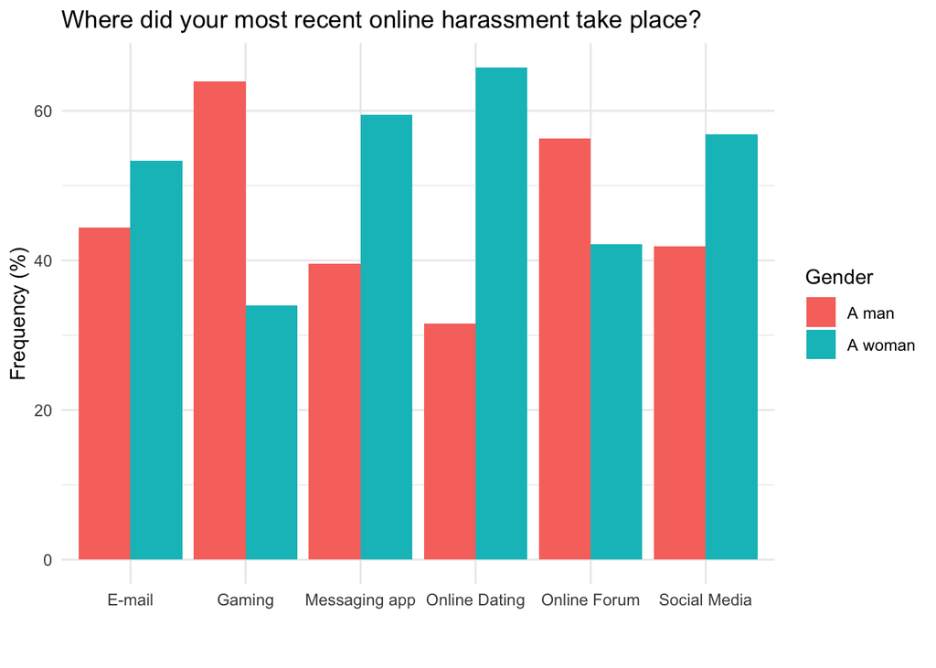

```r
## create a new df with the variables of interest. we can use starts_with to select columns based on a pattern, which is helpful for these items as any question with multiple answers in the pew dataset are labeled with a,b,c... and use the same question label:
df1 <- select(df, starts_with("ON12"), F_GENDER)
## selecting only 5 variables
# renaming the variables for easier reading
df1 <- df1 %>% rename("Social Media" = ON12_a_W74,"Online Dating" = ON12_b_W74,"Gaming" = ON12_e_W74, "E-mail" = ON12_f_W74, "Online Forum" = ON12_g_W74, "Messaging app" = ON12_h_W74)

# pivoting the data, i.e. making the separate data columns become a values in one column for plotting

df1 <- df1 %>%
  pivot_longer(!F_GENDER, names_to = "platform", values_to = "values")
# now it's a good time to click on your new df 1 (or type the code below)

view(df1)

# transforming factors, so that we have the gender and labels instead of number
df1$values <- as_factor(df1$values)
df1$F_GENDER <- as_factor(df1$F_GENDER)

view(df1)



## Creating a new dataframe that includes the percentages per platform for our plot (note that this is the same code we used in class)
x <- df1 %>%
  filter(values != "Refused") %>%
  group_by(platform, values, F_GENDER) %>%
  summarize(n = n(), na.rm = TRUE) %>% # removing NAs so we get valid percentages (for platform users) and not percentages overall which would include non-users
  mutate(perc = 100*n/sum(n))
# inspect again to see what the results are
view(x)
# check the x dataframe against the percentages you get with freq() -- if all looks good, move on to plotting:

#
x %>%
  filter(values == "Yes, it happened in this online environment",  F_GENDER == "A man" | F_GENDER == "A woman") %>%
  ggplot(aes(x= platform, y = perc, fill = F_GENDER)) +
  geom_bar(position = "dodge",stat = "identity") + #we changed stat to identity because we are providing the percentages in the dataframe instead of using counts
  labs(title = "Where did your most recent online harassment take place?", caption = "", x = "", y = "Frequency (%)", fill = "Gender") +
  theme_minimal()
```

**Note that you don’t have to do this for your own report**. This additional piece of code is only here to help those of you who are trying to combine columns and couldn’t figure out how to do it. With the exception of the pivoting part (making your dataframe long instead of wide), the code for everything else was already in other examples in this worksheet.

Good luck :)